# Practical Machine Learning - Course Project

AS

April 10, 2017

## Background

Using devices such as Jawbone Up, Nike FuelBand, and Fitbit it is now possible to collect a large amount of data about personal activity relatively inexpensively. These type of devices are part of the quantified self movement - a group of enthusiasts who take measurements about themselves regularly to improve their health, to find patterns in their behavior, or because they are tech geeks. One thing that people regularly do is quantify how much of a particular activity they do, but they rarely quantify how well they do it. In this project, your goal will be to use data from accelerometers on the belt, forearm, arm, and dumbell of 6 participants. They were asked to perform barbell lifts correctly and incorrectly in 5 different ways. More information is available from the website here: http://groupware.les.inf.puc-rio.br/har (see the section on the Weight Lifting Exercise Dataset).

### Data

The training data for this project are available here:  
https://d396qusza40orc.cloudfront.net/predmachlearn/pml-training.csv

The test data are available here:  
https://d396qusza40orc.cloudfront.net/predmachlearn/pml-testing.csv

The data for this project come from this source: http://groupware.les.inf.puc-rio.br/har.

## Executive Summary:

Using the data provided above, and the materials from the “Practical Machine Learning” lectures, this report summarizes the creation of a machine learning algorithm to predict the correct class of exercise from the data described above.

Topics covered in this report refer directly to the criteria for this project, namely:  
- How the model was built  
- How cross-validation was used  
- What the expected out-of-sample error is  
- Why certain choices were made

Each of these topics is covered in the report below, as well as sections on **data clean-up, feature selection, model parameters, and model evaluation.**

## Reading in & data, initial evaluation and clean-up:

### Read in the data:

‘na.strings’ argument was used to cleanly-identify missing data when data was read in so that it could later be deleted easily:

```r
training <- read.csv("pml-training.csv", header=TRUE, sep=",", na.strings = c("NA", ""))
testing <- read.csv("pml-testing.csv", header=TRUE, sep=",", na.strings = c("NA", ""))
```

### Initial data evaluation and exploration:

```r
table(training$user_name)
```

```
##
##   adelmo carlitos  charles   eurico   jeremy    pedro
##     3892     3112     3536     3070     3402     2610
```

```r
table(training$classe)
```

```
##
##    A    B    C    D    E
## 5580 3797 3422 3216 3607
```

Due to the broad scope of missing data, it was decided to omit columns with majority missing data from further analysis. A function was created for this purpose:

```r
# Created a Function to identify columns with lots of missing data:
miss <- function(x) {
        as.vector(apply(x, 2, function(x) length(which(is.na(x)))))
}
```

```r
# Put the identifier into a new vector and called it within the 'for' loop below (19216 represents the number of missing cases in each variable to be omitted):
countNA <- miss(training)
countNA
```

```
##   [1]     0     0     0     0     0     0     0     0     0     0     0
##  [12] 19216 19216 19216 19216 19216 19216 19216 19216 19216 19216 19216
##  [23] 19216 19216 19216 19216 19216 19216 19216 19216 19216 19216 19216
##  [34] 19216 19216 19216     0     0     0     0     0     0     0     0
##  [45]     0     0     0     0     0 19216 19216 19216 19216 19216 19216
##  [56] 19216 19216 19216 19216     0     0     0     0     0     0     0
##  [67]     0     0 19216 19216 19216 19216 19216 19216 19216 19216 19216
##  [78] 19216 19216 19216 19216 19216 19216     0     0     0 19216 19216
##  [89] 19216 19216 19216 19216 19216 19216 19216 19216 19216 19216 19216
## [100] 19216 19216     0 19216 19216 19216 19216 19216 19216 19216 19216
## [111] 19216 19216     0     0     0     0     0     0     0     0     0
## [122]     0     0     0 19216 19216 19216 19216 19216 19216 19216 19216
## [133] 19216 19216 19216 19216 19216 19216 19216     0 19216 19216 19216
## [144] 19216 19216 19216 19216 19216 19216 19216     0     0     0     0
## [155]     0     0     0     0     0     0
```

```r
omit <- c()
for (cnt in 1:ncol(training)) {
        if (countNA[cnt] == 19216) {
                omit <- c(omit, colnames(training)[cnt])
        }
}
```

```r
# Omit columns with lots of NA values from training and testing sets:
training <- training[, !(names(training) %in% omit)]
testing <- testing[, !(names(testing) %in% omit)]

# Verify remaining columns are the same in both training and testing sets (except training$classe and testing$problem_id):
colnames(training)
```

```
##  [1] "X"                    "user_name"            "raw_timestamp_part_1"
##  [4] "raw_timestamp_part_2" "cvtd_timestamp"       "new_window"
##  [7] "num_window"           "roll_belt"            "pitch_belt"
## [10] "yaw_belt"             "total_accel_belt"     "gyros_belt_x"
## [13] "gyros_belt_y"         "gyros_belt_z"         "accel_belt_x"
## [16] "accel_belt_y"         "accel_belt_z"         "magnet_belt_x"
## [19] "magnet_belt_y"        "magnet_belt_z"        "roll_arm"
## [22] "pitch_arm"            "yaw_arm"              "total_accel_arm"
## [25] "gyros_arm_x"          "gyros_arm_y"          "gyros_arm_z"
## [28] "accel_arm_x"          "accel_arm_y"          "accel_arm_z"
## [31] "magnet_arm_x"         "magnet_arm_y"         "magnet_arm_z"
## [34] "roll_dumbbell"        "pitch_dumbbell"       "yaw_dumbbell"
## [37] "total_accel_dumbbell" "gyros_dumbbell_x"     "gyros_dumbbell_y"
## [40] "gyros_dumbbell_z"     "accel_dumbbell_x"     "accel_dumbbell_y"
## [43] "accel_dumbbell_z"     "magnet_dumbbell_x"    "magnet_dumbbell_y"
## [46] "magnet_dumbbell_z"    "roll_forearm"         "pitch_forearm"
## [49] "yaw_forearm"          "total_accel_forearm"  "gyros_forearm_x"
## [52] "gyros_forearm_y"      "gyros_forearm_z"      "accel_forearm_x"
## [55] "accel_forearm_y"      "accel_forearm_z"      "magnet_forearm_x"
## [58] "magnet_forearm_y"     "magnet_forearm_z"     "classe"
```

```r
colnames(testing)
```

```
##  [1] "X"                    "user_name"            "raw_timestamp_part_1"
##  [4] "raw_timestamp_part_2" "cvtd_timestamp"       "new_window"
##  [7] "num_window"           "roll_belt"            "pitch_belt"
## [10] "yaw_belt"             "total_accel_belt"     "gyros_belt_x"
## [13] "gyros_belt_y"         "gyros_belt_z"         "accel_belt_x"
## [16] "accel_belt_y"         "accel_belt_z"         "magnet_belt_x"
## [19] "magnet_belt_y"        "magnet_belt_z"        "roll_arm"
## [22] "pitch_arm"            "yaw_arm"              "total_accel_arm"
## [25] "gyros_arm_x"          "gyros_arm_y"          "gyros_arm_z"
## [28] "accel_arm_x"          "accel_arm_y"          "accel_arm_z"
## [31] "magnet_arm_x"         "magnet_arm_y"         "magnet_arm_z"
## [34] "roll_dumbbell"        "pitch_dumbbell"       "yaw_dumbbell"
## [37] "total_accel_dumbbell" "gyros_dumbbell_x"     "gyros_dumbbell_y"
## [40] "gyros_dumbbell_z"     "accel_dumbbell_x"     "accel_dumbbell_y"
## [43] "accel_dumbbell_z"     "magnet_dumbbell_x"    "magnet_dumbbell_y"
## [46] "magnet_dumbbell_z"    "roll_forearm"         "pitch_forearm"
## [49] "yaw_forearm"          "total_accel_forearm"  "gyros_forearm_x"
## [52] "gyros_forearm_y"      "gyros_forearm_z"      "accel_forearm_x"
## [55] "accel_forearm_y"      "accel_forearm_z"      "magnet_forearm_x"
## [58] "magnet_forearm_y"     "magnet_forearm_z"     "problem_id"
```

### Evaluating the remaining (non-missing) variables:

The remaining variables were then evaluated for predictive potential relating to this classification problem:

```r
# Identify variables with Near Zero Variance:
nzv <- nearZeroVar(training, saveMetrics=TRUE)
nzv
```

```
##                      freqRatio percentUnique zeroVar   nzv
## X                     1.000000  100.00000000   FALSE FALSE
## user_name             1.100679    0.03057792   FALSE FALSE
## raw_timestamp_part_1  1.000000    4.26562022   FALSE FALSE
## raw_timestamp_part_2  1.000000   85.53154622   FALSE FALSE
## cvtd_timestamp        1.000668    0.10192641   FALSE FALSE
## new_window           47.330049    0.01019264   FALSE  TRUE
## num_window            1.000000    4.37264295   FALSE FALSE
## roll_belt             1.101904    6.77810621   FALSE FALSE
## pitch_belt            1.036082    9.37722964   FALSE FALSE
## yaw_belt              1.058480    9.97349913   FALSE FALSE
## total_accel_belt      1.063160    0.14779329   FALSE FALSE
## gyros_belt_x          1.058651    0.71348486   FALSE FALSE
## gyros_belt_y          1.144000    0.35164611   FALSE FALSE
## gyros_belt_z          1.066214    0.86127816   FALSE FALSE
## accel_belt_x          1.055412    0.83579655   FALSE FALSE
## accel_belt_y          1.113725    0.72877383   FALSE FALSE
## accel_belt_z          1.078767    1.52379982   FALSE FALSE
## magnet_belt_x         1.090141    1.66649679   FALSE FALSE
## magnet_belt_y         1.099688    1.51870350   FALSE FALSE
## magnet_belt_z         1.006369    2.32901845   FALSE FALSE
## roll_arm             52.338462   13.52563449   FALSE FALSE
## pitch_arm            87.256410   15.73234125   FALSE FALSE
## yaw_arm              33.029126   14.65701763   FALSE FALSE
## total_accel_arm       1.024526    0.33635715   FALSE FALSE
## gyros_arm_x           1.015504    3.27693405   FALSE FALSE
## gyros_arm_y           1.454369    1.91621649   FALSE FALSE
## gyros_arm_z           1.110687    1.26388747   FALSE FALSE
## accel_arm_x           1.017341    3.95984099   FALSE FALSE
## accel_arm_y           1.140187    2.73672409   FALSE FALSE
## accel_arm_z           1.128000    4.03628580   FALSE FALSE
## magnet_arm_x          1.000000    6.82397309   FALSE FALSE
## magnet_arm_y          1.056818    4.44399144   FALSE FALSE
## magnet_arm_z          1.036364    6.44684538   FALSE FALSE
## roll_dumbbell         1.022388   84.20650290   FALSE FALSE
## pitch_dumbbell        2.277372   81.74498012   FALSE FALSE
## yaw_dumbbell          1.132231   83.48282540   FALSE FALSE
## total_accel_dumbbell  1.072634    0.21914178   FALSE FALSE
## gyros_dumbbell_x      1.003268    1.22821323   FALSE FALSE
## gyros_dumbbell_y      1.264957    1.41677709   FALSE FALSE
## gyros_dumbbell_z      1.060100    1.04984201   FALSE FALSE
## accel_dumbbell_x      1.018018    2.16593619   FALSE FALSE
## accel_dumbbell_y      1.053061    2.37488533   FALSE FALSE
## accel_dumbbell_z      1.133333    2.08949139   FALSE FALSE
## magnet_dumbbell_x     1.098266    5.74864948   FALSE FALSE
## magnet_dumbbell_y     1.197740    4.30129447   FALSE FALSE
## magnet_dumbbell_z     1.020833    3.44511263   FALSE FALSE
## roll_forearm         11.589286   11.08959331   FALSE FALSE
## pitch_forearm        65.983051   14.85577413   FALSE FALSE
## yaw_forearm          15.322835   10.14677403   FALSE FALSE
## total_accel_forearm   1.128928    0.35674243   FALSE FALSE
## gyros_forearm_x       1.059273    1.51870350   FALSE FALSE
## gyros_forearm_y       1.036554    3.77637346   FALSE FALSE
## gyros_forearm_z       1.122917    1.56457038   FALSE FALSE
## accel_forearm_x       1.126437    4.04647844   FALSE FALSE
## accel_forearm_y       1.059406    5.11160942   FALSE FALSE
## accel_forearm_z       1.006250    2.95586586   FALSE FALSE
## magnet_forearm_x      1.012346    7.76679238   FALSE FALSE
## magnet_forearm_y      1.246914    9.54031189   FALSE FALSE
## magnet_forearm_z      1.000000    8.57710733   FALSE FALSE
## classe                1.469581    0.02548160   FALSE FALSE
```

Only ‘new_window’ variable is listed as having near zero variance, but this - along with the timestamp variables - will not be used for prediction due to their irrelevance to the classification problem. They are omitted below:

```r
table(training$new_window)
```

```
##
##    no   yes
## 19216   406
```

```r
# training$new_window is listed as near zero variance, but will be omitted:
training <- select(training, 8:60)
testing <- select(testing, 8:60)
```

Further evaluation was performed on the remaining variables to analyze normalcy and correlations between variables:

```r
# In order to look at our data in bulk, we should group all numerics together using 'select' from <dplyr>:
dat.matrix <- as.matrix(select(training, 1:52))

# we can now look at normality stats for all numeric vars:
skew <- apply(dat.matrix, 2, skewness)
skew
```

```
##            roll_belt           pitch_belt             yaw_belt
##          -0.01619542          -1.00151381           0.90719284
##     total_accel_belt         gyros_belt_x         gyros_belt_y
##           0.03488594          -0.58294610          -0.05517356
##         gyros_belt_z         accel_belt_x         accel_belt_y
##           0.20723195           0.97168883           0.15615609
##         accel_belt_z        magnet_belt_x        magnet_belt_y
##           0.02028705           1.43315194          -2.23584119
##        magnet_belt_z             roll_arm            pitch_arm
##           0.17267171          -0.17605357           0.20338590
##              yaw_arm      total_accel_arm          gyros_arm_x
##          -0.09192407           0.06498848          -0.28769108
##          gyros_arm_y          gyros_arm_z          accel_arm_x
##           0.13521149          -0.17068782           0.34240753
##          accel_arm_y          accel_arm_z         magnet_arm_x
##           0.09821943          -0.84936842          -0.15495033
##         magnet_arm_y         magnet_arm_z        roll_dumbbell
##          -0.46739507          -1.14036244          -0.73953144
##       pitch_dumbbell         yaw_dumbbell total_accel_dumbbell
##           0.52234973           0.21686225           0.59752220
##     gyros_dumbbell_x     gyros_dumbbell_y     gyros_dumbbell_z
##        -126.32122065          31.64827373         135.95343721
##     accel_dumbbell_x     accel_dumbbell_y     accel_dumbbell_z
##          -0.45952472           0.35405691          -0.10050065
##    magnet_dumbbell_x    magnet_dumbbell_y    magnet_dumbbell_z
##           1.69402391          -1.80978684           0.87760332
##         roll_forearm        pitch_forearm          yaw_forearm
##          -0.46440330          -0.51029624          -0.26672992
##  total_accel_forearm      gyros_forearm_x      gyros_forearm_y
##          -0.57832461          -1.92378622          51.32379243
##      gyros_forearm_z      accel_forearm_x      accel_forearm_y
##         116.07619371          -0.22936368          -0.65061431
##      accel_forearm_z     magnet_forearm_x     magnet_forearm_y
##           0.43641836           0.64329521          -0.74446997
##     magnet_forearm_z
##          -1.22106091
```

```r
summary(skew)
```

```
##       Min.    1st Qu.     Median       Mean    3rd Qu.       Max.
## -126.30000   -0.52730   -0.03568    3.88200    0.37460  136.00000
```

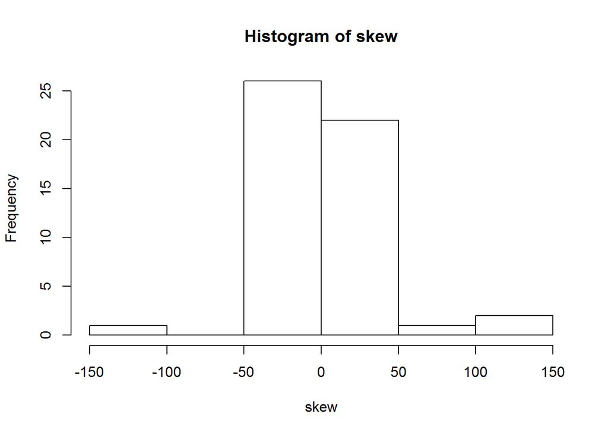

```r
hist(skew)
```

```r
kurt <- apply(dat.matrix, 2, kurtosis)
kurt
```

```
##            roll_belt           pitch_belt             yaw_belt
##        -1.931423e+00        -9.148150e-02        -5.825986e-01
##     total_accel_belt         gyros_belt_x         gyros_belt_y
##        -1.753249e+00         6.555312e+00         4.718405e+00
##         gyros_belt_z         accel_belt_x         accel_belt_y
##         6.287342e+00        -9.353187e-02        -1.569365e+00
##         accel_belt_z        magnet_belt_x        magnet_belt_y
##        -1.834606e+00         2.099836e+00         7.973007e+00
##        magnet_belt_z             roll_arm            pitch_arm
##         1.234808e+01        -4.099837e-01         2.848569e-01
##              yaw_arm      total_accel_arm          gyros_arm_x
##        -1.314055e-01        -2.878825e-01        -4.312016e-01
##          gyros_arm_y          gyros_arm_z          accel_arm_x
##         6.461085e-01         4.123372e-02        -7.842971e-01
##          accel_arm_y          accel_arm_z         magnet_arm_x
##        -1.039067e+00         8.815773e-01        -1.600661e+00
##         magnet_arm_y         magnet_arm_z        roll_dumbbell
##        -8.287751e-01         1.000597e-01        -4.405801e-01
##       pitch_dumbbell         yaw_dumbbell total_accel_dumbbell
##        -1.333361e-01        -1.429286e+00        -8.276839e-01
##     gyros_dumbbell_x     gyros_dumbbell_y     gyros_dumbbell_z
##         1.709348e+04         2.681477e+03         1.885261e+04
##     accel_dumbbell_x     accel_dumbbell_y     accel_dumbbell_z
##         1.067656e+00        -4.297979e-01        -5.432732e-01
##    magnet_dumbbell_x    magnet_dumbbell_y    magnet_dumbbell_z
##         1.443158e+00         2.781936e+00         2.745407e-01
##         roll_forearm        pitch_forearm          yaw_forearm
##        -7.578136e-01         8.781658e-01        -1.142683e+00
##  total_accel_forearm      gyros_forearm_x      gyros_forearm_y
##         1.042816e+00         6.988494e+01         5.150217e+03
##      gyros_forearm_z      accel_forearm_x      accel_forearm_y
##         1.527176e+04        -6.899268e-01        -1.174921e-01
##      accel_forearm_z     magnet_forearm_x     magnet_forearm_y
##        -9.104490e-01        -7.741406e-02        -4.552205e-01
##     magnet_forearm_z
##         8.995480e-01
```

```r
summary(kurt)
```

```
##      Min.   1st Qu.    Median      Mean   3rd Qu.      Max.
##    -1.931    -0.707    -0.093  1137.000     1.607 18850.000
```

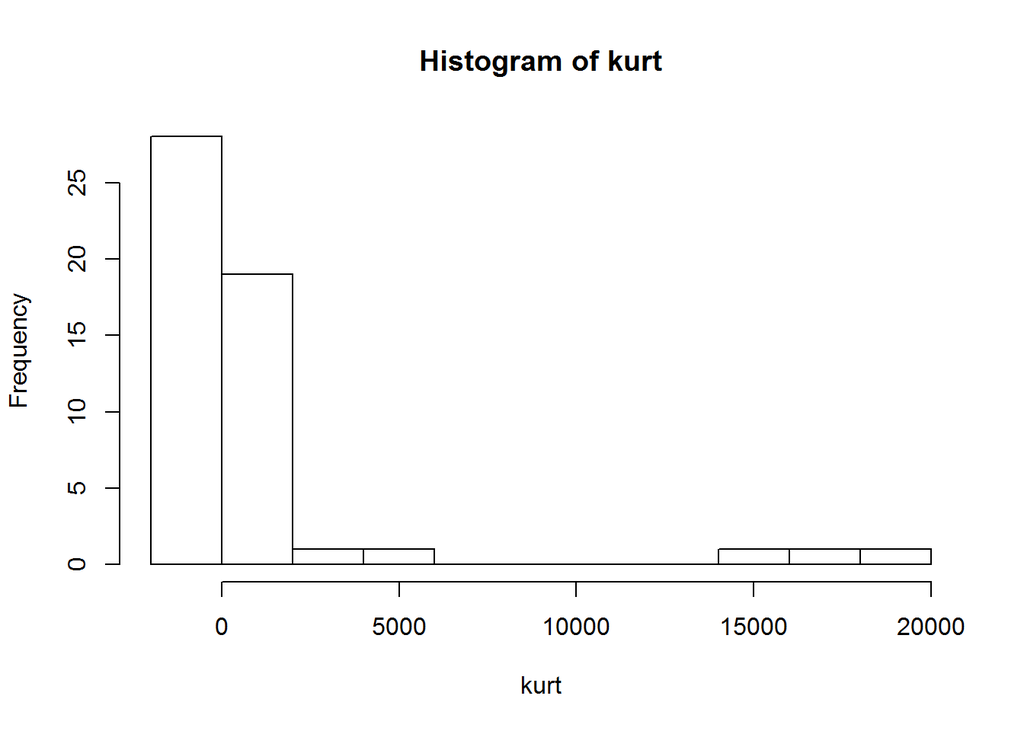

```r
hist(kurt)
```

Some of these variables exhibit skewness and kurtosis, which may impact our analysis depending on the model’s robustness to non-normal data. Therefore, some pre-processing may be necessary to make the data more normal & improve overall model performance.

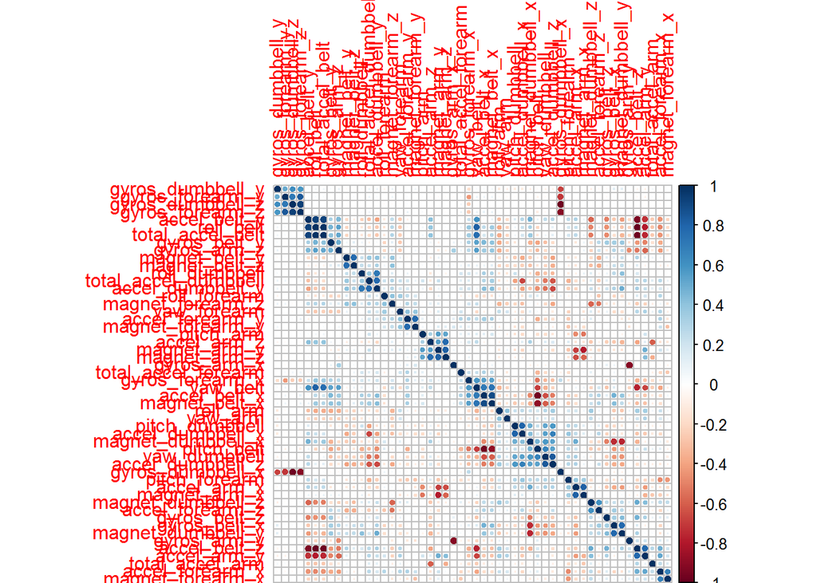

```r
# plotting correlations:
corrplot(correlations, order = "hclust")
```

```r
# identify highly-correlated variables for potential deletion:
highCor <- findCorrelation(correlations, cutoff = .75) # returns column numbers
highCor
```

```
##  [1] 10  1  9 22  4 36  8  2 37 35 38 21 34 23 25 13 48 45 31 33 18
```

There are also several variables which exhibit significant between-variable correlation and should be omitted to simplify our analysis:

```r
# Omit columns of highly-correlated variables from training and testing sets:
training <- training[, -highCor]
testing <- testing[, -highCor]
```

## Splitting Initial Training Data into Training and Validation Sets:

Now that the data sets have been evaluated and cleaned-up, we can prepare for modeling.  
Based on the extremely small size of the testing set (n = 20), the training data was further broken down into “train1” and “val1” training and validation sets:

```r
set.seed(342)
train_sample <- createDataPartition(y = training$classe,
                                  p = .6,
                                  list = FALSE)

train1 <- training[train_sample,]
val1 <- training[-train_sample,]
```

## Establishing a Baseline Model for comparison purposes:

A true **random guess baseline model** would simply guess each of the 5 classes approx. 3924 times (1/5 of the time)

```r
table(training$classe)
```

```
##
##    A    B    C    D    E
## 5580 3797 3422 3216 3607
```

```r
prop.table(table(training$classe))
```

```
##
##         A         B         C         D         E
## 0.2843747 0.1935073 0.1743961 0.1638977 0.1838243
```

### Baseline #1:

We can improve on the “random guess” model by constructing a simple decision tree model on ‘train1’ using all default settings, with no pre-processing or cross-validation:

```r
set.seed(342)
baseMod <- train(classe ~ .,
                 data = train1,
                 method = "rpart")
baseMod
```

```
## CART
##
## 11776 samples
##    31 predictor
##     5 classes: 'A', 'B', 'C', 'D', 'E'
##
## No pre-processing
## Resampling: Bootstrapped (25 reps)
## Summary of sample sizes: 11776, 11776, 11776, 11776, 11776, 11776, ...
## Resampling results across tuning parameters:
##
##   cp          Accuracy   Kappa
##   0.02313716  0.5480283  0.4298855
##   0.02711201  0.5238431  0.4001287
##   0.04218083  0.3903343  0.1796518
##
## Accuracy was used to select the optimal model using  the largest value.
## The final value used for the model was cp = 0.02313716.
```

```r
baseMod$finalModel
```

```
## n= 11776
##
## node), split, n, loss, yval, (yprob)
##       * denotes terminal node
##
##   1) root 11776 8428 A (0.28 0.19 0.17 0.16 0.18)
##     2) pitch_forearm< -26.45 1066   47 A (0.96 0.044 0 0 0) *
##     3) pitch_forearm>=-26.45 10710 8381 A (0.22 0.21 0.19 0.18 0.2)
##       6) magnet_belt_y>=555.5 9817 7489 A (0.24 0.23 0.21 0.18 0.15)
##        12) yaw_belt>=169.5 466   45 A (0.9 0.052 0 0.045 0) *
##        13) yaw_belt< 169.5 9351 7145 B (0.2 0.24 0.22 0.19 0.16)
##          26) magnet_dumbbell_z< -93.5 1129  463 A (0.59 0.28 0.049 0.053 0.03) *
##          27) magnet_dumbbell_z>=-93.5 8222 6224 C (0.15 0.23 0.24 0.2 0.17)
##            54) roll_dumbbell< 59.01819 5186 3402 C (0.18 0.18 0.34 0.14 0.15)
##             108) magnet_forearm_z< 343.5 1883 1370 B (0.23 0.27 0.15 0.13 0.21)
##               216) yaw_belt< -88.15 827  411 B (0.18 0.5 0.17 0.059 0.081) *
##               217) yaw_belt>=-88.15 1056  729 E (0.27 0.092 0.13 0.19 0.31) *
##             109) magnet_forearm_z>=343.5 3303 1805 C (0.14 0.13 0.45 0.15 0.12) *
##            55) roll_dumbbell>=59.01819 3036 2096 B (0.11 0.31 0.07 0.3 0.21)
##             110) total_accel_dumbbell>=5.5 2143 1256 B (0.083 0.41 0.058 0.19 0.25) *
##             111) total_accel_dumbbell< 5.5 893  381 D (0.16 0.059 0.1 0.57 0.11) *
##       7) magnet_belt_y< 555.5 893  181 E (0.0011 0.0022 0.0011 0.2 0.8) *
```

### Candidate Model #1: Decision Tree with some pre-processing:

The model below builds on the simple baseline model by adding some pre-processing in order to deal with the non-normal characteristics of the data seen during the Exploration phase:

```r
set.seed(342)
can1Mod <- train(classe ~ .,
                 data = train1,
                 preProcess=c("center", "scale", "BoxCox"),
                 method = "rpart")
can1Mod
```

```
## CART
##
## 11776 samples
##    31 predictor
##     5 classes: 'A', 'B', 'C', 'D', 'E'
##
## Pre-processing: centered (31), scaled (31), Box-Cox transformation (2)
## Resampling: Bootstrapped (25 reps)
## Summary of sample sizes: 11776, 11776, 11776, 11776, 11776, 11776, ...
## Resampling results across tuning parameters:
##
##   cp          Accuracy   Kappa
##   0.02313716  0.5480376  0.4298965
##   0.02711201  0.5238524  0.4001398
##   0.04218083  0.3903343  0.1796518
##
## Accuracy was used to select the optimal model using  the largest value.
## The final value used for the model was cp = 0.02313716.
```

### Candidate 2: Decision Tree with pre-processing, and cross-validation:

The model below includes 2 repeats of 10-fold cross-validation in order to build on candidate model 1.

```r
modelLookup("rpart")
```

```
##   model parameter                label forReg forClass probModel
## 1 rpart        cp Complexity Parameter   TRUE     TRUE      TRUE
```

```r
set.seed(342)

# Set resampling method using 'trainControl' from Caret pkg:
train_control <- trainControl(method = "repeatedcv", # type of resampling
                              number = 10,           # number of folds
                              repeats = 2)           # repeats of whole process

can2Mod <- train(classe ~ .,
                 data = train1,
                 preProcess = c("center", "scale", "BoxCox"),
                 trControl = train_control,
                 method = "rpart")

can2Mod
```

```
## CART
##
## 11776 samples
##    31 predictor
##     5 classes: 'A', 'B', 'C', 'D', 'E'
##
## Pre-processing: centered (31), scaled (31), Box-Cox transformation (2)
## Resampling: Cross-Validated (10 fold, repeated 2 times)
## Summary of sample sizes: 10600, 10599, 10599, 10600, 10597, 10597, ...
## Resampling results across tuning parameters:
##
##   cp          Accuracy   Kappa
##   0.02313716  0.5574061  0.4420018
##   0.02711201  0.5221239  0.3998359
##   0.04218083  0.4056406  0.2087238
##
## Accuracy was used to select the optimal model using  the largest value.
## The final value used for the model was cp = 0.02313716.
```

### Candidate 3: Random Forest model with pre-processing and cross-validation:

Based on previous efforts (including the candidate models above), the lecture notes, and the Skewness/Kurtosis characteristics of the data, it seems that both pre-processing and cross-validation will lead to improved model performance:

```r
can3Mod
```

```
## Random Forest
##
## 11776 samples
##    31 predictor
##     5 classes: 'A', 'B', 'C', 'D', 'E'
##
## Pre-processing: centered (31), scaled (31), Box-Cox transformation (2)
## Resampling: Cross-Validated (10 fold, repeated 2 times)
## Summary of sample sizes: 10600, 10599, 10599, 10600, 10597, 10597, ...
## Resampling results across tuning parameters:
##
##   mtry  Accuracy   Kappa
##    2    0.9878570  0.9846373
##   16    0.9871343  0.9837239
##   31    0.9766053  0.9704062
##
## Accuracy was used to select the optimal model using  the largest value.
## The final value used for the model was mtry = 2.
```

```r
can3Mod$finalModel
```

```
##
## Call:
##  randomForest(x = x, y = y, mtry = param$mtry)
##                Type of random forest: classification
##                      Number of trees: 500
## No. of variables tried at each split: 2
##
##         OOB estimate of  error rate: 1.1%
## Confusion matrix:
##      A    B    C    D    E  class.error
## A 3345    2    1    0    0 0.0008960573
## B   22 2249    8    0    0 0.0131636683
## C    0   29 2011   14    0 0.0209347614
## D    1    0   38 1888    3 0.0217616580
## E    0    0    4    7 2154 0.0050808314
```

The random forest model shows much better accuracy (98.7%), as well as confusion matrix and OOB error estimates which are much better than previous attempts. This model will be used as our “Final Model” & will be measured against the validation and test data sets.

## Using the Final Model to Predict on Validation Set:

Due to the high accuracy of the random forest model (candidate #3), predictions will be made to the validation set for confirmation of final model selection:

```r
### Predict on the validation set:
preds <- predict(can3Mod, newdata=val1)
confusionMatrix(preds, val1$classe)
```

```
## Confusion Matrix and Statistics
##
##           Reference
## Prediction    A    B    C    D    E
##          A 2230    4    0    0    0
##          B    2 1505   23    0    2
##          C    0    9 1341   18    0
##          D    0    0    4 1261    1
##          E    0    0    0    7 1439
##
## Overall Statistics
##
##                Accuracy : 0.9911
##                  95% CI : (0.9887, 0.993)
##     No Information Rate : 0.2845
##     P-Value [Acc > NIR] : < 2.2e-16
##
##                   Kappa : 0.9887
##  Mcnemar's Test P-Value : NA
##
## Statistics by Class:
##
##                      Class: A Class: B Class: C Class: D Class: E
## Sensitivity            0.9991   0.9914   0.9803   0.9806   0.9979
## Specificity            0.9993   0.9957   0.9958   0.9992   0.9989
## Pos Pred Value         0.9982   0.9824   0.9803   0.9961   0.9952
## Neg Pred Value         0.9996   0.9979   0.9958   0.9962   0.9995
## Prevalence             0.2845   0.1935   0.1744   0.1639   0.1838
## Detection Rate         0.2842   0.1918   0.1709   0.1607   0.1834
## Detection Prevalence   0.2847   0.1953   0.1744   0.1614   0.1843
## Balanced Accuracy      0.9992   0.9936   0.9880   0.9899   0.9984
```

## Using Predictions on Validation Set to Evaluate Out-Of-Sample Error Rate:

Now that predictions have been made on new data, we can estimate our out-of-sample error rate as follows:

```r
# Out-of-sample error rate: The error rate on a new data set - ie, from the validation set:
errorRate <- 1 - .9911
errorRate
```

```
## [1] 0.0089
```

## Final predictions on the Testing set:

To fulfill the assignment’s final requirement that predictions be made on the 20 observations in the Testing set, the final model was used to predict those values and submitted as Week 4’s Quiz:

```r
finalPreds <- predict(can3Mod, newdata=testing)
finalPreds
```

```
##  [1] B A B A A E D B A A B C B A E E A B B B
## Levels: A B C D E
```

## Summary:

- We began with a thorough understanding of our data and the question at hand (ie, the project criteria)
- Training and Testing data were read in, evaluated, explored, and cleaned as needed to provide the best predictions possible
- The original data was simplified based on a few standard methods
- Several candidate models were built and evaluated using our understanding of the data and modeling techniques
- A final model was selected based on accuracy characteristics, overall classification, and out-of-sample error estimates
- The final model was applied to the validation data set for confirmation, and ultimately to the Testing set for final predictions which will be submitted as Week 4’s Quiz answers in order to fulfill the requirements of this Project and Course.